# QA NLI Scores - IAS (atomic_bm)

Published

September 18, 2026

# IAS – granularity: atomic_bm – nli_config: bge_m3_zeroshot_atomic_bm

## Methodology

This report is a **QA check on Phase 1 (zero-shot NLI) scoring, not a scoring result in its own right** — it lets each claim’s scored citing works be spot-checked by eye (title, abstract, DOI, label, confidence, and the underlying class probabilities), and shows the overall SUPPORTS/REFUTES/NOT_ENOUGH_INFO x confidence distribution. It covers **Phase 1 only** — see `QA_LLM_Verification_Report.qmd` for the equivalent Phase 2 (LLM verification) QA report. See `TD_BM_NLI_approach.qmd` for the full NLI approach and `TD_NLI_LLM_two_phase.qmd` for how Phase 2 builds on this.

```r
if (isTRUE(x$empty)) {
  cat("No scored data available yet for this assessment/granularity/config combination — Phase 1 hasn't produced output here.\n\n")
  knitr::knit_exit()
}
```

```r
cat(sprintf(
  "- **%s** scored (claim, citing work) pairs in total\n",
  format(x$n_total, big.mark = ",")
))
```

- **686,020** scored (claim, citing work) pairs in total

```r
cat(sprintf(
  "- The table below shows up to **%d** highest-confidence rows per claim (**%s** rows shown here, out of the %s total) — every claim's own true row count is carried in the `n_total_claim` column so no truncation is silent; use the filters or the confusion matrix above for the full picture\n",
  x$per_claim_cap, format(x$n_shown, big.mark = ","), format(x$n_total, big.mark = ",")
))
```

[output not shown]

## Label x confidence matrix

REFUTES/SUPPORTS/NOT_ENOUGH_INFO counts across confidence deciles, computed on the **full** scored dataset (not the capped table below).

```r
knitr::kable(x$matrix)
```

| label | 0.3-0.4 | 0.4-0.5 | 0.5-0.6 | 0.6-0.7 | 0.7-0.8 | 0.8-0.9 | 0.9-1.0 |
| --- | --- | --- | --- | --- | --- | --- | --- |
| SUPPORTS | 33778 | 97751 | 61094 | 28966 | 11293 | 3139 | 358 |
| NOT_ENOUGH_INFO | 35981 | 118780 | 98236 | 63189 | 27525 | 5489 | 119 |
| REFUTES | 32812 | 50691 | 13275 | 2992 | 466 | 71 | 15 |

## Class probability distribution (ternary)

Since `p_supports + p_refutes + p_nei = 1` always, every row’s three class probabilities live on a 2D triangular surface rather than filling a 3D volume — this is the standard way to show exactly that kind of 3-part composition losslessly in 2D. Each corner is 100% one label; a point’s position encodes all three probabilities at once, and its color is the local **density** of scored pairs at that combination (log-scaled so structure is visible everywhere, not just at the tallest peaks). The three solid, coloured lines are the actual decision boundaries — where the winning label flips from one to another — running from the centroid out to each edge’s midpoint; each corner’s percentage is the real share of rows that label actually won.

The black dashed triangle is the **certain/uncertain boundary**: `label` is always the argmax of the three probabilities (which line above a point falls on decides that), but `confidence` — the *winning* probability — is a separate question, and a row is `uncertain` whenever `confidence` is below this granularity’s own `uncertain_threshold` (shown in the legend). Points inside the dashed triangle are `uncertain` regardless of which label technically won there; only the three small corners beyond it are `certain`. A label can be assigned with real confidence right up against this line while still counting as uncertain — the two are independent judgements, not the same thing read two ways.

When available, small white markers overlay the actual **key papers** — the seed/reference works IPBES cites as evidence for a BM, scored against that same BM’s claim (averaged across whatever claims exist under that BM — we don’t yet have claim-level evidence-to-paper mapping, only BM-level) — as a QA sanity check: a key paper *is* the evidence a BM was written from, so it should overwhelmingly land in the SUPPORTS region; if it doesn’t, that’s worth investigating, not a normal finding. Each corner’s bracketed percentage is the key papers’ own share for that label, next to the full-corpus share, so the two can be compared directly, followed by the p-value from a two-proportion test (key-paper share vs. full-corpus share for that corner) — a small p-value means the key-paper share is genuinely different from the full-corpus one, not just sampling noise from the much smaller key-paper count. This overlay comes from a separate scoring pass (`nli_scores_keypaper_evidence`) that now runs automatically alongside the main citing-works scoring — it’s absent here only on a cold first build, before that chain has produced anything yet.

```r
if (length(ternary_path)) {
  cat(sprintf('<img src="%s" style="max-width:100%%;"><br><br>\n\n', xfun::base64_uri(ternary_path)))
}
```

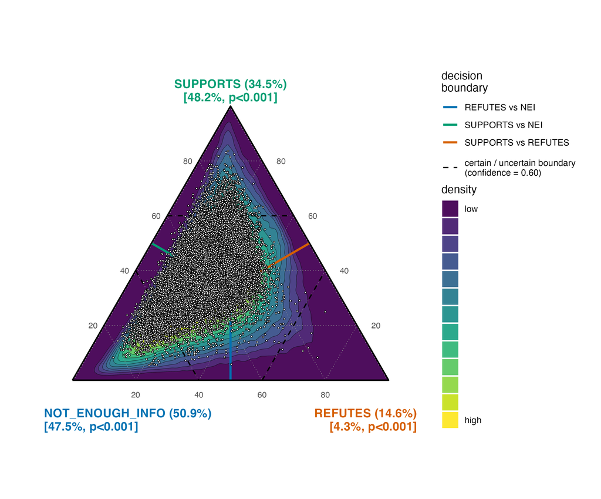

```r
if (!is.null(x$keypaper_summary)) {
  r <- x$keypaper_summary
  cat(sprintf(
    "**Key paper validation:** of **%d** key papers, **%.1f%%** landed in SUPPORTS\n\n",
    r$n, r$pct_supports
  ))
}
```

**Key paper validation:** of **40587** key papers, **48.2%** landed in SUPPORTS

## Claims and scores

Use the filter row below the header to narrow by KM, BM, claim, or label.

```r
x$widget
```

| km | bm | claim_id | claim | work | title | abstract | label | confidence | p_supports | p_refutes | p_nei | n_total_claim |
| --- | --- | --- | --- | --- | --- | --- | --- | --- | --- | --- | --- | --- |
| KM-A1 | A1 | bm_description-01 | Alien species (plants, animals, fungi and microorganisms, including pathogens) are being introduced globally at an unprecedented rate; currently, approximately 200 new alien species are recorded every… | 10.1111/maec.12331 | Epiphyte assemblages of the Mediterranean seagrassPosidonia oceanica: an overview | Abstract This paper reviews the main studies dealing with epiphytes of both leaves and rhizomes ofPosidonia oceanica, the main seagrass found in the Mediterranean Sea. A total of 660 epiphyte species … | NOT_ENOUGH_INFO | 0.868 | 0.051 | 0.081 | 0.868 | 7189 |
| KM-A1 | A1 | bm_description-01 | Alien species (plants, animals, fungi and microorganisms, including pathogens) are being introduced globally at an unprecedented rate; currently, approximately 200 new alien species are recorded every… | 10.1002/fsh.10176 | Commercial Fisheries of the Upper Mississippi River: A Century of Sustained Harvest | Abstract Commercial harvest is often considered as a primary cause of fish population declines in marine and inland systems throughout the world. However, much of the data supporting the negative attr… | NOT_ENOUGH_INFO | 0.86 | 0.061 | 0.079 | 0.86 | 7189 |
| KM-A1 | A1 | bm_description-01 | Alien species (plants, animals, fungi and microorganisms, including pathogens) are being introduced globally at an unprecedented rate; currently, approximately 200 new alien species are recorded every… | 10.1007/978-3-032-19616-3_6 | Wildlife | Abstract A wide variety of wildlife species occur in red spruce ( Picea rubens ) and spruce-fir forests, and these forest types represent optimal habitat for several vertebrate and invertebrate specie… | NOT_ENOUGH_INFO | 0.856 | 0.047 | 0.097 | 0.856 | 7189 |
| KM-A1 | A1 | bm_description-01 | Alien species (plants, animals, fungi and microorganisms, including pathogens) are being introduced globally at an unprecedented rate; currently, approximately 200 new alien species are recorded every… | 10.1016/j.aquabot.2019.103166 | Hybridization with natives augments the threats of introduced species in Sonneratia mangroves |  | SUPPORTS | 0.853 | 0.853 | 0.078 | 0.068 | 7189 |
| KM-A1 | A1 | bm_description-01 | Alien species (plants, animals, fungi and microorganisms, including pathogens) are being introduced globally at an unprecedented rate; currently, approximately 200 new alien species are recorded every… | 10.3153/ar25011 | Biodiversity of marine macroalgae in Oran coast (Algerian west coast – Mediterranean Sea) | This work aims to establish the current state of knowledge of the macroalgae on the Oran coast. This research used a survey method using three stations (Marsa El Hadjaj, Kristel and Ain Franine). Samp… | NOT_ENOUGH_INFO | 0.851 | 0.052 | 0.097 | 0.851 | 7189 |
| KM-A1 | A1 | bm_description-01 | Alien species (plants, animals, fungi and microorganisms, including pathogens) are being introduced globally at an unprecedented rate; currently, approximately 200 new alien species are recorded every… | 10.1038/s41597-024-04026-0 | A global dataset of salmonid biomass in streams | Salmonid fishes are arguably one of the most studied fish taxa on Earth, but little is known about their biomass range in many parts of the world. We created a dataset of estimated salmonid biomass us… | NOT_ENOUGH_INFO | 0.848 | 0.066 | 0.086 | 0.848 | 7189 |
| KM-A1 | A1 | bm_description-01 | Alien species (plants, animals, fungi and microorganisms, including pathogens) are being introduced globally at an unprecedented rate; currently, approximately 200 new alien species are recorded every… | 10.1111/1744-7917.70274 | Co‐invasion of multiple invasive ants exacerbates the impacts on native ant communities | The structure and function of native ant communities are increasingly threatened by the growing number of biological invaders spread around the world. Although the detrimental impacts of single-specie… | SUPPORTS | 0.844 | 0.844 | 0.063 | 0.093 | 7189 |
| KM-A1 | A1 | bm_description-01 | Alien species (plants, animals, fungi and microorganisms, including pathogens) are being introduced globally at an unprecedented rate; currently, approximately 200 new alien species are recorded every… | 10.1608/frj-2.2.2 | Fisheries and Cichlid Evolution in the African Great Lakes: Progress and Problems | This paper updates Recent Advances in the African Great Lakes: Fisheries, Biodiversity and Cichlid Evolution published by the Freshwater Biological Association in Freshwater Forum (Lowe-McConnell, 200… | NOT_ENOUGH_INFO | 0.841 | 0.058 | 0.101 | 0.841 | 7189 |
| KM-A1 | A1 | bm_description-01 | Alien species (plants, animals, fungi and microorganisms, including pathogens) are being introduced globally at an unprecedented rate; currently, approximately 200 new alien species are recorded every… | 10.1016/j.marpol.2025.106899 | Marine recreational fisheries in Uruguay: Current status, challenges and opportunities for research and management | Marine Recreational Fisheries (MRF) have significant economic, socio-cultural and ecological value globally, contributing up to 12 % of the world's finfish catch. In South America, participation in MR… | NOT_ENOUGH_INFO | 0.824 | 0.07 | 0.106 | 0.824 | 7189 |
| KM-A1 | A1 | bm_description-01 | Alien species (plants, animals, fungi and microorganisms, including pathogens) are being introduced globally at an unprecedented rate; currently, approximately 200 new alien species are recorded every… | 10.1139/cjfas-2025-0429 | Abundance trends within the freshwater mussel assemblages of seven major southwestern Ontario rivers | Freshwater mussels are important components of aquatic ecosystems, yet represent one of the most imperiled taxa worldwide. The Unionid Monitoring and Biodiversity Observation network was established t… | NOT_ENOUGH_INFO | 0.819 | 0.075 | 0.106 | 0.819 | 7189 |

[output cut: 4590 more lines]